# S4: Kraljevo Case Study - The Prior Risk Model

For the Kraljevo case study, this notebook presents the available input data, the major components of the risk model and the simulation workflow. This notebook focuses on those parts that are specific to this case-study and different from the general and more detailed description in the notebook for the Zurich Case Study.

Available input data | Risk model | Simulation workflow

```python
import pandas as pd
import numpy as np
import matplotlib.pyplot as plt
import os
```

## Available input data

For each building the available input data consists of:

- Easting in km ('x')
- Northing in km ('y')
- Construction year ('const_year')
- Number of stories above ground ('num_stories')
- Zip code ('zip')
- Eurocode8 Soil Class ('SoilClassEC')

```python
path_Data = os.path.join(os.getcwd(), 'Kraljevo', 'Data') + os.sep
dfBuil = pd.read_csv(path_Data + 'BuildingInfo.csv')
dfInput = dfBuil[['x', 'y', 'SoilClassEC', 'const_year', 'num_stories', 'zip']].copy()
# Geo-coordinates in km
dfInput['x'] /= 1000
dfInput['y'] /= 1000
dfInput
```

|  | x | y | SoilClassEC | const_year | num_stories | zip |
| --- | --- | --- | --- | --- | --- | --- |
| 0 | 7475.349501 | 4843.283329 | C | 1998 | 2 | 3 |
| 1 | 7475.710517 | 4843.737321 | B | 1990 | 2 | 3 |
| 2 | 7475.519505 | 4843.371325 | C | 1990 | 2 | 3 |
| 3 | 7474.802518 | 4843.944349 | C | 1994 | 2 | 3 |
| 4 | 7474.876120 | 4843.578204 | B | 1997 | 2 | 3 |
| ... | ... | ... | ... | ... | ... | ... |
| 1954 | 7475.057372 | 4839.043316 | C | 1967 | 2 | 1 |
| 1955 | 7475.420437 | 4841.136316 | C | 1967 | 1 | 1 |
| 1956 | 7475.391435 | 4841.095317 | C | 1968 | 1 | 1 |
| 1957 | 7475.570443 | 4841.309312 | C | 1970 | 2 | 1 |
| 1958 | 7475.328447 | 4841.476321 | C | 1936 | 1 | 1 |

1959 rows × 6 columns

The event characteristics for this example consist of the earthquake magnitude ('M'), easting and northing coordinates of the epicenter in km ('x','y') and the type-of-faulting ('Faulting'), here strike-slip.

|  | M | Lon | Lat | Faulting | Source | x | y |
| --- | --- | --- | --- | --- | --- | --- | --- |
| 0 | 5.5 | 20.71 | 43.76 | SS | RS | 7477.0841 | 4846.205303 |

```python
from CodePaper.rmgp.modules import EventChar
df_EC = df_EC.squeeze()
EC = EventChar(Magnitude=df_EC.M, xEpi = df_EC.x, yEpi = df_EC.y,
               style_of_faulting=df_EC.Faulting)
```

## Risk model

Ground motion module | Damage module | Typological attribution module

In contrast to the notebook S1 (Zurich Case Study), this notebook presents the prior risk model directly in its object-oriented implementation, used in the risk-model informed gaussian process (RMGP). The code of RMGP is publicly available.

### Ground motion module

This module builds upon an empirical ground-motion model (GMM) and an empirical spatial correlation model to simulate random fields of a ground-motion intensity measure (IM) conditional on a scenario earthquake with characteristics $\mathbf{e}$. The GMM provides the mean function and the standard deviation of the between-event and within-event residual. The spatial correlation model provides the lengthscale used for the covariance function of the within-event residual. Here we use elastic, 5% damped spectral acceleration at T=0.3 seconds as IM, the GMM of Akkar and Bommer [1] and the spatial correlation model of Esposito and Iervolino [2].

The object SpatialGMM combines a ground-motion model and a spatial correlation model. This is the first module of the RMGP.

References

[1] Akkar, S. and Bommer J.J. (2010): Empirical Equations for the Prediction of PGA, PGV, and Spectral Accelerations in Europe, the Mediterranean Region, and the Middle East; Seismological Research Letters, 81(2):195-206; 10.1785/gssrl.81.2.195

[2] Esposito, S. and Iervolino, I. (2012): Spatial Correlation of Spectral Acceleration in European Data; Bulletin of the Seismological Society of America, 102(6):2781–2788; 10.1785/012012006

```python
# Load the GMM
from CodePaper.rmgp.gmm_lib.gmms import GMM_AkkarBommer2010
from CodePaper.rmgp.modules import SpatialGMM

path_gmm_coeff = 'CodePaper/rmgp/gmm_lib/AB10_PanEuropeanGMPE_coeffs.csv'
GMM = GMM_AkkarBommer2010(column_names = ['x','y','SoilClassEC'],
                          path_coeff = path_gmm_coeff)

T = 0.3 # PGA
corr_length = 15.3 # Estimated from European data by Esposito and Iervolino (2012)
SpGMM = SpatialGMM(GMM, corr_length, T)
```

### Damage module

First, load the vulnerability functions in a dataframe ('df_frag'). The herein employed vulnerability functions have been published in [1] and the different vulnerability types are chosen based on [2].

The vulnerability function parameters are specified for 12 different classes $b\in\mathcal{B}=\{1,2,...,12\}$, namely adobe structure ('ADO'), unreinforced masonry structures with two different brick technologies ('URM_A') and ('URM_B'), and confined masonry structures from three different construction periods ('MCF_A', 'MCF_B' and 'MCF_C'), where each type is further separated into low-rise (1-2 storeys) and mid-rise (3-4 storeys) buildings. Because the dataset is limited to single-family houses, there are no buildings with more than 4 storeys.

The dataframe below shows the considered typology name of the original vulnerability functions as published in [1].

References

[1] Martins, L. and Silva, V. (2021): Development of a fragility and vulnerability model for global seismic risk analyses; Bulletin of Earthquake Engineering 19:6719-6745; 10.1007/s10518-020-00885-1

[2] Stojadinovic, Z. Kovacevic, M. Marinkovic, D. and Stojadinovic, B. (2021): Rapid earthquake loss assessment based on machine learning and representative sampling; Earthquake Spectra 38(1):152-177; 10.1177/87552930211042393

|  | Type | HeightClass | original_typology |
| --- | --- | --- | --- |
| 0 | ADO | LR | MUR-ADO_LWAL-DNO_H2 |
| 1 | ADO | MR | MUR-ADO_LWAL-DNO_H3 |
| 2 | URM_A | LR | MUR-CL99_LWAL-DNO_H2 |
| 3 | URM_A | MR | MUR-CL99_LWAL-DNO_H3 |
| 4 | URM_B | LR | MUR-CB99_LWAL-DNO_H2 |
| 5 | URM_B | MR | MUR-CB99_LWAL-DNO_H3 |
| 6 | MCF_A | LR | MCF_LWAL-DUL_H2 |
| 7 | MCF_A | MR | MCF_LWAL-DUL_H3 |
| 8 | MCF_B | LR | MCF_LWAL-DUM_H2 |
| 9 | MCF_B | MR | MCF_LWAL-DUM_H3 |
| 10 | MCF_C | LR | MCF_LWAL-DUH_H2 |
| 11 | MCF_C | MR | MCF_LWAL-DUH_H3 |

Then arrange the threshold parameters in matrix $\boldsymbol{\eta}$ ('etas') and the dispersion parameters in vector $\boldsymbol{\beta}$ ('betas'). The initially chosen functions employ 4+1 damage states, whereas in the current model we consider 3+1 damage states $y\in\mathcal{Y}=\{0,1,2,3\}$. Specifically, we lump the damage states 2 and 3 used by the vulnerability functions to $y=2$. The original damage state 4 becomes then $y=3$.

The object DamageEstimationModule collects the vulnerability function parameters $\boldsymbol{\eta}$ and $\boldsymbol{\beta}$. It transforms these parameters into a GPflow likelihood object that is used for inference using inspection data. This is the second module of the RMGP.

```python
etas = np.log(df_frag.iloc[:, 3:-1].values)
betas = df_frag.iloc[:, -1].values.reshape(-1,1)

mask = np.isin(np.arange(4),[0,1,3])
etas = etas[:,mask]

from CodePaper.rmgp.modules import DamageEstimationModule

DEM = DamageEstimationModule(etas, betas)
```

The following Figure illustrates the vulnerability functions of three classes.

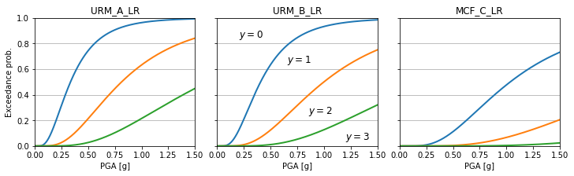

### Typological attribution module

The present model categorizes residential buildings in the case-study region into four unkown typological attribute combinations $a\in\mathcal{A}=\{1,2,3,4\}$:

- $a=1$ : Adobe ('ADO')
- $a=2$ : Unreinforced masonry with old brick technology ('URM_A')
- $a=3$ : Unreinforced masonry with new brick technology ('URM_B')
- $a=4$ : (Partially) confined masonry ('MCF')

These attribute combinations are modelled via four latent functions $\mathbf{g}$ that follow independent gaussian processes with an identical covariance function but different mean functions. Conditional on realizations from these four latent functions, the class membership probabilities $p(A=a|\mathbf{g},\mathbf{X})$ are calculated via the softmax function. Conditional on the sampled attribute combinations and the input information, we then map to the vulnerability types from above using a deterministic function. The following paragraphs walk you through the different parts of the model starting with the mean function.

#### Mean functions

The mean functions of the latent functions $\mathbf{g}$ are based on an expert-based attribution model that comes in the form of a conditional probability table. Specifically, the herein assumed model provides class membership probabilities conditional on six construction periods. The table is shown below.

|  | ConPeriod | p_ADO | p_URM_A | p_URM_B | p_MCF |
| --- | --- | --- | --- | --- | --- |
| 0 | cy $\leq$ 1933 | 0.6 | 0.4 | 0.00 | 0.00 |
| 1 | 1933 $<$ cy $\leq$ 1950 | 0.4 | 0.0 | 0.60 | 0.00 |
| 2 | 1950 $<$ cy $\leq$ 1963 | 0.0 | 0.0 | 0.50 | 0.50 |
| 3 | 1963 $<$ cy $\leq$ 1975 | 0.0 | 0.0 | 0.30 | 0.70 |
| 4 | 1975 $<$ cy $\leq$ 1990 | 0.0 | 0.0 | 0.15 | 0.85 |
| 5 | cy $>$ 1990 | 0.0 | 0.0 | 0.05 | 0.95 |

We employ a smoothed version of this table via the introduction of sigmoid terms at the discrete boundaries of the different construction periods. The code below shows the formula and the figure illustrates the resulting functions.

```python
# Add a small value to zero entries and normalize such that the rows sum up to one
AttMat = df_am.iloc[:, 1:].values
AttMat[AttMat==0] += 0.001
AttMat = AttMat / np.sum(AttMat,axis=1).reshape(-1,1)

def mean_prior_prob_ta(df_target, AttMat):
    C_A = AttMat.shape[1]
    Xm = np.zeros((len(df_target), C_A))
    yb = df_target['const_year'].values
    for bc in np.arange(C_A):
        Xm[:, bc] = (
            AttMat[0,bc] + (AttMat[1,bc]-AttMat[0,bc]) * 1/(1+np.exp(-0.5*(yb-1933))) +
            (AttMat[2,bc]-AttMat[1,bc]) * 1/(1+np.exp(-0.5*(yb-1950))) +
            (AttMat[3,bc]-AttMat[2,bc]) * 1/(1+np.exp(-0.5*(yb-1963))) +
            (AttMat[4,bc]-AttMat[3,bc]) * 1/(1+np.exp(-0.5*(yb-1975))) +
            (AttMat[5,bc]-AttMat[4,bc]) * 1/(1+np.exp(-0.5*(yb-1990))) )
    return Xm
```

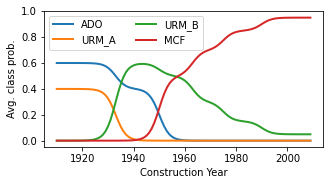

#### Covariance function

The covariance function of the gaussian process is identical to the Zurich case study and the reader is referred to notebook S1.

```python
from CodePaper.rmgp.modules import TypologyAttributionModule
col_names = ['x', 'y', 'const_year', 'num_stories']
TAM = TypologyAttributionModule(AttMat,
                          column_names = col_names,
                          column_dtypes = dfInput[col_names].dtypes,
                          func_assign_vul_class = None,
                          func_prior_mean_prob = mean_prior_prob_ta)
```

The joint prior distribution of latent functions $\mathbf{g}=( \mathbf{g}^{(a)} | a \in \mathcal{A})$ evaluated at the building sites $\mathbf{X}$ follow four independent multivariate normal distributions $p(\mathbf{g^{(a)}}|\mathbf{X}) = \mathcal{N}(\mathbf{u^{(a)}},\mathbf{V})$. Using the TypologyAttributionModule object, the code below shows how to evaluate the mean vector and covariance matrix for the first five buildings.

```python
u = TAM.mean_func(dfInput.iloc[:5])
V = TAM.cov_func(dfInput.iloc[:5])
```

#### Deterministic mapping to vulnerability types

```python
def AssignVulClass(sim_a, df_target):
    num_story = df_target['num_stories'].values
    con_year = df_target['const_year'].values
    sim_b = 2 * sim_a
    # Separate height classes according to number of stories
    sim_b += (num_story<=2) * 0 + ((num_story>2)) * 1
    # For MCF buildings: Separate buildings according to the construction year.
    sim_b += (
        ((sim_a >= 2) * ((con_year > 1975) & (con_year <= 1990))) * 2 +
        ((sim_a >= 2) * (con_year > 1990)) * 4
        )
    return sim_b.astype('int')
TAM.func_assign_vul_class = AssignVulClass
```

### RMGP Implemenation

The RMGP object combines the three modules explained above and takes the event characteristics as an additional input. This object is used for prediction and inference using data from building inspections. The inference workflow is explained in the example notebook in the GitLab repository, while the simulation workflow is illustrated below.

```python
from CodePaper.rmgp.model import RMGP
rmgp = RMGP(SpGMM, TAM, DEM, EC)
```

## Simulation workflow

The code below illustrates the simulation workflow for 'numB' buildings and 'numSim' simulations. For a step-by-step explanation the reader is referred to notebook S1.

```python
numB = 100
numSim = 10
dftarget = dfInput.sample(n=numB)
```

```python
sam_n = rmgp.Sample_damage(dftarget, numSim, aggregate=True).T
```